# Binary Linear Regression Analysis of Two Palmetto Models

Kiera Matiska

1/31/2022

# Overview:

In this code, two models will be analyzed using binary linear regression to decide which of the two models is the best one for determining two different palmetto species: *Serenoa repens* and *Sabal etonia*. Before running the models, three graphs will be generated to determine which variables seem significant for the models. The variables that will be used withing the two models are length in centimeters, height in centimeters, width in centimeters, and number of green leaves each individual has. In the end, a final model will be chosen and will be analyzed to determine the likelihood of it choosing the correct species based on its variables and coefficients.

```r
knitr::opts_chunk$set(echo = TRUE, message = FALSE, warning = FALSE)

# attach packages
library(tidyverse)
library(here)
library(GGally)
library(AICcmodavg)
library(broom)
library(caret)
library(jtools)
library(kableExtra)
library(equatiomatic)
```

```r
palmetto <- read_csv("palmetto.csv") # read in data
```

## Data Visualizations

```r
palmetto_species <- palmetto %>% # define subset
  mutate(species = case_when( # rename species
    species == "1" ~ "Serenoa repens",
    species == "2" ~ "Sabal etonia"
  ))

palmetto_subset <- palmetto_species %>% # define new subset
  select(species, height:green_lvs) %>% # only keep these columns
  drop_na() # drop na values
```

### Plot 1

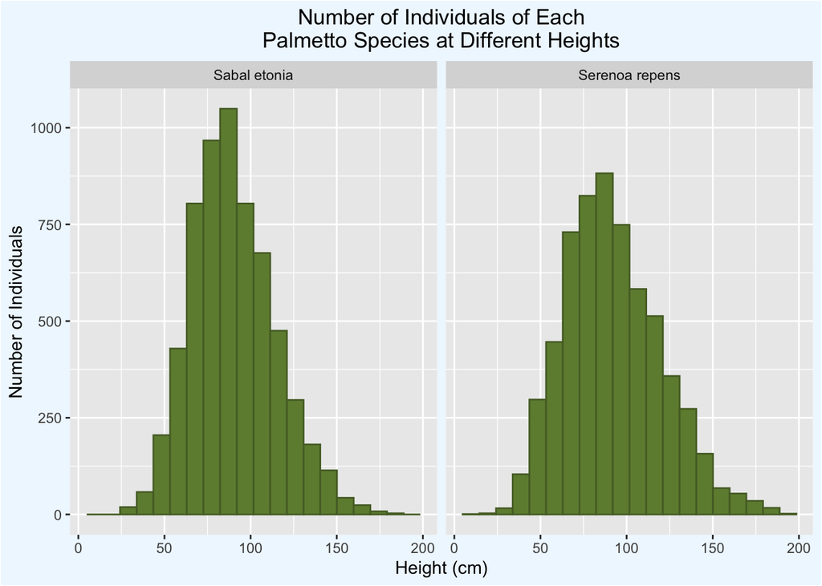

```r
# wrangle data
palmetto_sum1 <- palmetto_subset %>%
  group_by(species) %>%
  summarize(max_height = max(height), # find max height
            min_height = min(height), # find min height
            mean_height = mean(height), # calculate mean height
            sd_height = sd(height), # calculate the dtandard deviation
            species_count = n()) # count the number of individuals of each species

# histogram on height and number of individuals
ggplot(data = palmetto_subset, # define ggplot
       aes(x = height)) +
  geom_histogram(bins = 20, fill = "darkolivegreen4", color = "darkolivegreen") + # define histogram and change colors
  facet_wrap(~ species) + # separate data by species
  labs(title = "Number of Individuals of Each\nPalmetto Species at Different Heights", # add title
       x = "Height (cm)", # add x-axis label
       y = "Number of Individuals") + # add y-axis label
  theme(plot.title = element_text(hjust = 0.5), # center title
        plot.background = element_rect(fill = "aliceblue")) # change background color
```

### Plot 2

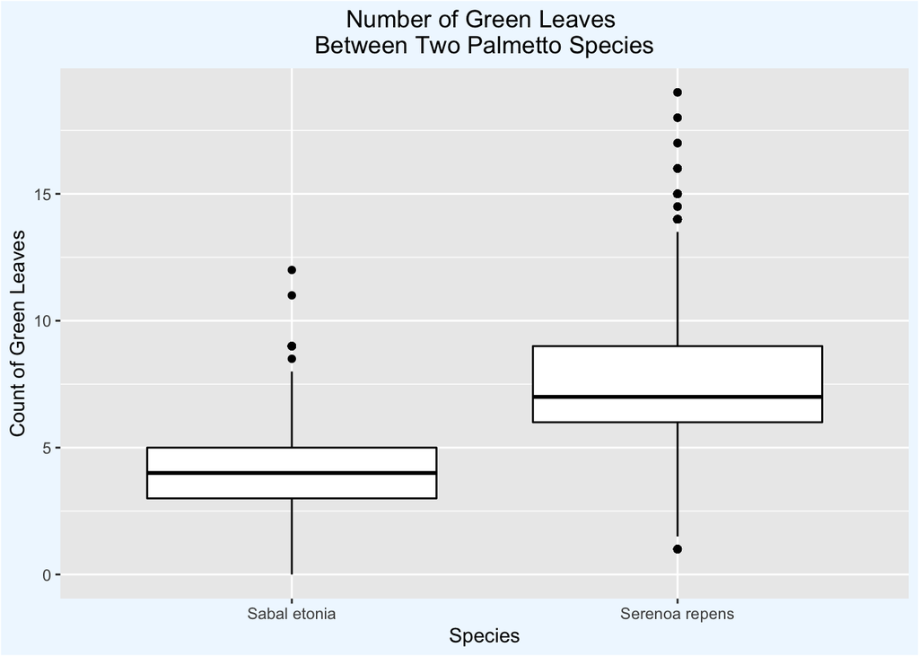

```r
# wrangle data for plot 2
palmetto_sum2 <- palmetto_subset %>% # define new subset
  group_by(species) %>%
  summarize(max_leaves = max(green_lvs), # find max number of leaves
            min_leaves = min(green_lvs), # find minimum number of leaves
            median_leaves = median(green_lvs), # calculate median number of leaves
            mean_leaves = mean(green_lvs), # calculate mean number of leaves
            count = n()) # count species

# create a box plot showing green leave count differences by species
ggplot(data = palmetto_subset, # define ggplot
       aes(x = species, y = green_lvs)) +
  geom_boxplot(color = "black") + # define box plot and chose color
  labs(title = "Number of Green Leaves \nBetween Two Palmetto Species", # add title
       x = "Species", # add x-axis label
       y = "Count of Green Leaves") + # add y-axis label
  theme_gray() + # change theme
  theme(plot.title = element_text(hjust = 0.5), # center title
        plot.background = element_rect(fill = "aliceblue")) # change background color
```

### Plot 3

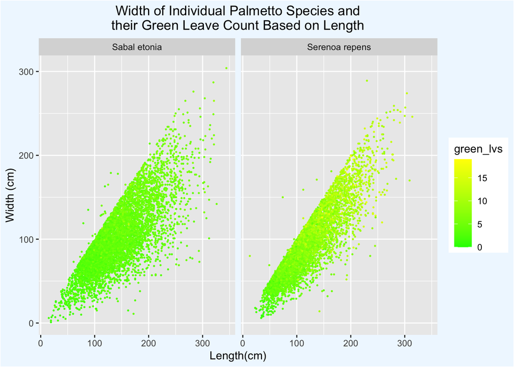

```r
# create a scatter plot plotting length against width colored by the number of green leaves an individual has
ggplot(data = palmetto_subset, # define data set
       aes(x = length, y = width)) +
  geom_point(aes(color = green_lvs), # define scatter plot and change colors
             size = 0.3) + # resize dots
  facet_wrap(~ species) + # separate data by species
  scale_color_gradient(low = "green", high = "yellow") + # change gradient color
  labs(title = "Width of Individual Palmetto Species and\ntheir Green Leave Count Based on Length", # add title
       x = "Length(cm)", # add x-axis
       y = "Width (cm)") + # add y-axis
  theme(plot.title = element_text(hjust = 0.5), # center title
        plot.background = element_rect(fill = "aliceblue")) # change background color
```

**Figure 3.** Width of Individual Palmetto Species and their Green Leave Count Based on Length. Width is measured in centimeters and is a function of the length of an individual, also in centimeters. Number of green leaves is also graphed based on both length and width, with 19 being the maximum number of leaves and 0 being the smallest number of leaves on an individual.

## Conclusion

Based on these graphs, it looks like length, width, and green leaves will be good predictor variables for the determination of which species the palmetto is.

## Binary Linear Regression Model

```r
palmetto_blr_subset <- palmetto_subset %>% # create a blr subset
  mutate(species = fct_drop(species)) %>% # create a factor of species
  drop_na() # drop na values

# levels: 1. Sabal etonia, 2. Serenow repens

f1 <- species ~ height + length + width + green_lvs # formula 1
f2 <- species ~ height + width + green_lvs # formula 2

# run generalized linear model (glm) of model 1
palm_species_blr1 <- glm(formula = f1,
                         data = palmetto_blr_subset,
                         family = "binomial")
# run glm of model 2
palm_species_blr2 <- glm(formula = f2,
                         data = palmetto_blr_subset,
                         family = "binomial")

# palm_species_blr1
# palm_species_blr2

# summary(palm_species_blr1)
# summary(palm_species_blr2)



# AICc(palm_species_blr1) # 5194.57
# AICc(palm_species_blr2) # 5987.48

# aictab(list(palm_species_blr1, palm_species_blr2)) # Delta AIC: 792.91




set.seed(123) # so we don't get random numbers each time we run it

tr_ctrl <- trainControl(method = "repeatedcv", number = 10, repeats = 10) # set train control model

# train the model
model1 <- train(f1, data = palmetto_blr_subset, # train model 1
                method = "glm", family = "binomial",
                trControl = tr_ctrl)
# model1 # return model 1

model2 <- train(f2, data = palmetto_blr_subset, # train model 2
                method = "glm", family = "binomial",
                trControl = tr_ctrl)

# model2 # return model 2




# final model: model 1; run glm
final_palmetto_model <- glm(formula = f1,
                            data = palmetto_blr_subset,
                            family = "binomial")

summary_final <- summary(final_palmetto_model) # create a summary table

# find fitted values using broom::augment
final_fitted <- final_palmetto_model %>%
  broom::augment(type.predict = "response") %>%
  mutate(fitted = .fitted) %>%
  mutate(species = as.character(species))

# create a new table with the odds of the model
final_fitted_odds <- final_fitted %>% # define new subset
  select(species:green_lvs, fitted) %>% # choose certain columns for new subset
  mutate(fitted = fitted * 100) %>% # find percentage
  mutate(suspected_species = case_when(
    fitted >= 50 ~ "Serenoa repens",
    fitted < 50 ~ "Sabal etonia"
  ))




model_correct <- final_fitted_odds %>% # define new subset
  mutate(species_correct = case_when( # determine whether the model calculated the right or wrong species
    species == "Serenoa repens" & suspected_species == "Serenoa repens" ~ 1,
    species == "Serenoa repens" & suspected_species != "Serenoa repens" ~ 0,
    species == "Sabal etonia" & suspected_species == "Sabal etonia" ~ 4,
    species == "Sabal etonia" & suspected_species != "Sabal etonia" ~ 3,
  ))

# create a summary table with the right and wrong species
model_sum <- model_correct %>%
  group_by(species_correct) %>%
  summarize(count = n())

# rename and calculate some variable observations
model_sum_sub <- model_sum %>%
  mutate(species_correct = case_when( # rename observations
    species_correct == "1" ~ "Serenoa repens Correct",
    species_correct == "0" ~ "Serenoa repens Incorrect",
    species_correct == "4" ~ "Sabal etonia Correct",
    species_correct == "3" ~ "Sabal etonia Incorrect"
  )) %>%
  mutate(species_percent = case_when( # calculate observations
    count == "564" ~ round(count[1]/(count[1] + count[2]) * 100, 2),
    count == "5548" ~ round(count[2]/(count[1] + count[2]) * 100, 2),
    count == "454" ~ round(count[3]/(count[3] + count[4]) * 100, 2),
    count == "5701" ~ round(count[4]/(count[3] + count[4]) * 100, 2)
  ))
```

**Table 1.** Percent of Species Observations Guessed Correctly and Incorrectly by the Model

```r
# create a table with the data collected above
model_sum_sub %>%
  kbl(col.names = c("Species", # change column header names
                    "Count",
                    "Percentage (%)")) %>%
  kable_styling(position = "center", full_width = TRUE) # style the table
```

| Species | Count | Percentage (%) |
| --- | --- | --- |
| Serenoa repens Incorrect | 564 | 9.23 |
| Serenoa repens Correct | 5548 | 90.77 |
| Sabal etonia Incorrect | 454 | 7.38 |
| Sabal etonia Correct | 5701 | 92.62 |

```r
# create a tidy version of the final model coefficient data
final_palm_tidy <- broom::tidy(final_palmetto_model) %>%
  mutate(term = case_when( # rename the term intercepts
    term == "(Intercept)" ~ "Intercept",
    term == "height" ~ "Height",
    term == "length" ~ "Length",
    term == "width" ~ "Width",
    term == "green_lvs" ~ "Green Leaves"
  )) %>%
  mutate(p.value = if(p.value < 0.001) { # if any p value is below 0.001, replace it with 0.001
      paste("<0.001")
  }
    else{
      paste(p.value)
    }
  )
```

**Table 2.** Coefficient Estimates and Statistical Values for Each Coefficient

```r
# create a table of the tidy data set above
final_palm_tidy %>%
  kbl(col.names = c("Variable", # change column names
                    "Coefficient",
                    "Standard Error",
                    "Statistic",
                    "P Value"),
      digits = c(0, 2, 3, 2, 3)) %>% # changes number of digits seen in each column
  kable_styling(position = "center", full_width = TRUE) # style the table
```

| Variable | Coefficient | Standard Error | Statistic | P Value |
| --- | --- | --- | --- | --- |
| Intercept | -3.23 | 0.142 | -22.71 | <0.001 |
| Height | 0.03 | 0.002 | 12.67 | <0.001 |
| Length | -0.05 | 0.002 | -24.56 | <0.001 |
| Width | -0.04 | 0.002 | -18.78 | <0.001 |
| Green Leaves | 1.91 | 0.039 | 49.11 | <0.001 |

## Conclusion

Based on the statistical analysis above, model 1 is the best model because it has the lowest AIC value (5194.57) and the p-values all show significance among each variable. Model 2 has an AIC value that is almost 800 above model 1 and only two of the three variables show significance. These two things on top of the binary linear regression test indicates that model 1 is the best model. This is the equation:

$$\begin{aligned}
\log\left[ \frac { \widehat{P( \operatorname{species} = \operatorname{Serenoa\ repens} )} }{ 1 - \widehat{P( \operatorname{species} = \operatorname{Serenoa\ repens} )} } \right] &= -3.23 + 0.03(\operatorname{height}) - 0.05(\operatorname{length}) - 0.04(\operatorname{width})\ + \\
&\quad 1.91(\operatorname{green\_lvs})
\end{aligned}$$

Overall, the model appears to be around 91% effective, which is excellent for determining a species based on these variables.

#### Data Citation

Abrahamson, W.G. 2019. Survival, growth and biomass estimates of two dominant palmetto species of south-central Florida from 1981 - 2017, ongoing at 5-year intervals ver 1. Environmental Data Initiative. https://doi.org/10.6073/pasta/f2f96ec76fbbd4b9db431c79a770c4d5